# Random Forest - Attrition

Adrian Jenkins

9/3/2021

The dataset is composed of 1470 observations and 35 attributes. For this model we will be using 21 out of the original 35 attributes. The variables to include are the following: “Age”, “Attrition”, “Business Travel”, “Department”, “Distance From Home”, “Education”, “Education Field”, “Environment Satisfaction”, “Gender”, “Hourly Rate”, “Job Involvement”, “Job Level”, “Job Role”, “Job Satisfaction”, “Marital Status”, “Monthly Income”, “Monthly Rate”, “OverTime”, “Relationship Satisfaction”, “Work Life Balance” and “Years At Company”.

Dataset contains no missing values and needed transformation has already been done. We will create a random forest model to predict “Attrition”, which refers to whether the employee left or not the company.

The first step is to generate a seed to ensure reproducibility of the results and divide the dataset into a training and a testing set.

Training data will contain 75% of the original data and the remaining 25% will be for the testing dataset:

```r
set.seed(1)
attrition_split <- initial_split(attrition, strata = Attrition)
attrition_train <- training(attrition_split)
attrition_test <- testing(attrition_split)
attrition_split
```

[output not shown]

## Random Forest Model

```r
modelo_rf <- randomForest(Attrition ~., data = attrition_train, importance = TRUE, proximity = TRUE)
print(modelo_rf)
```

```
##
## Call:
##  randomForest(formula = Attrition ~ ., data = attrition_train,      importance = TRUE, proximity = TRUE)
##                Type of random forest: classification
##                      Number of trees: 500
## No. of variables tried at each split: 4
##
##         OOB estimate of  error rate: 14.08%
## Confusion matrix:
##      No Yes class.error
## No  911  13  0.01406926
## Yes 142  35  0.80225989
```

It is interesting to note the six most important variables considered by the model:

```
##                       No       Yes MeanDecreaseAccuracy MeanDecreaseGini
## MonthlyIncome   8.664398  8.498192           12.4039719         31.13030
## Age             9.307553  6.386116           11.3270275         28.19252
## MonthlyRate    -1.296143 -1.728128           -1.9491414         23.35417
## OverTime       16.931865 24.589179           25.9143636         21.40028
## HourlyRate      1.215400 -3.421533           -0.6131718         20.38684
## YearsAtCompany  2.261443  7.570881            5.9248305         20.32534
```

These are the first six variables with a higher Mean Decrease Gini. A high value indicates greater importance. It can be seen that the model gave greater weight to the variables “Monthly Income”, “Age” and “Monthly Rate”. This confirms what we might have expected: monthly income is a determining factor for the employee when deciding whether or not to leave the company.

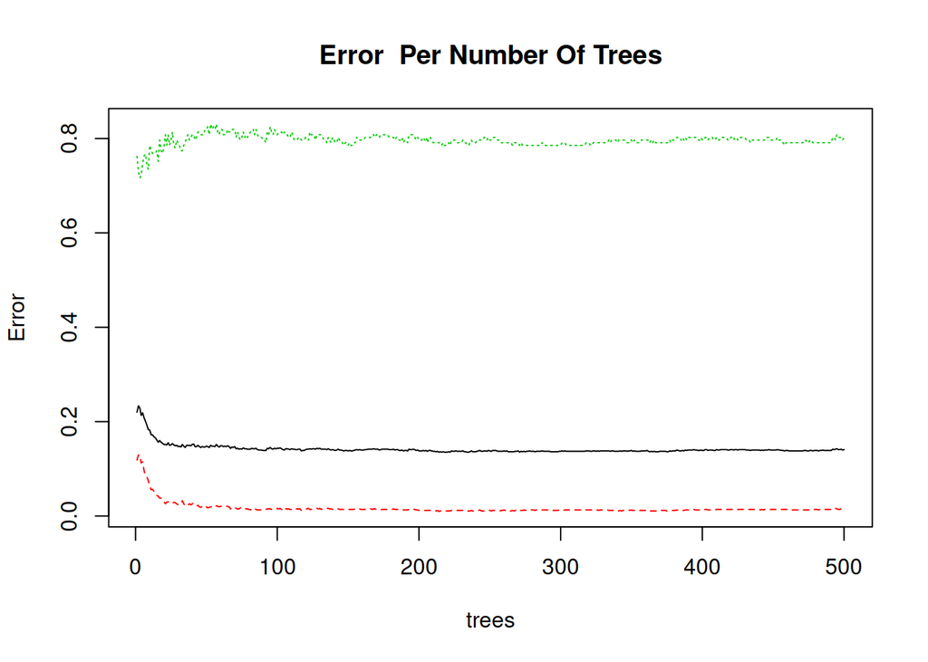

Once the model has been built, prediction and evaluation are carried out:

```
##       Prediction
## Actual  No Yes
##    No  307   2
##    Yes  47  13
```

```
## [1] "Accuracy: 0.867209"
```

```
## [1] "Precision: 0.866667"
```

```
## [1] "Recall: 0.216667"
```

```
## [1] "Specificity: 0.993528"
```

```
## [1] "F1 score: 0.346667"
```

**Specificity** is defined as: TN/TN+FP. This value represents the ratio in which, out of all the observations belonging to the negative class, how many were correctly predicted by the model. For this case, out of a total of 309 people who did not leave the company, the model correctly predicts 99.3% of the observations.

The AUC is a graphical representation that illustrates the trade-off between specificity and sensitivity. The closer it approaches the 45-degree diagonal, the less accurate the model. Whereas, the closer it approaches the upper left corner indicates better performance. Below is the ROC Curve and different values where the company should make a decision as a cut-off point, based on its needs and what it is willing to tolerate.

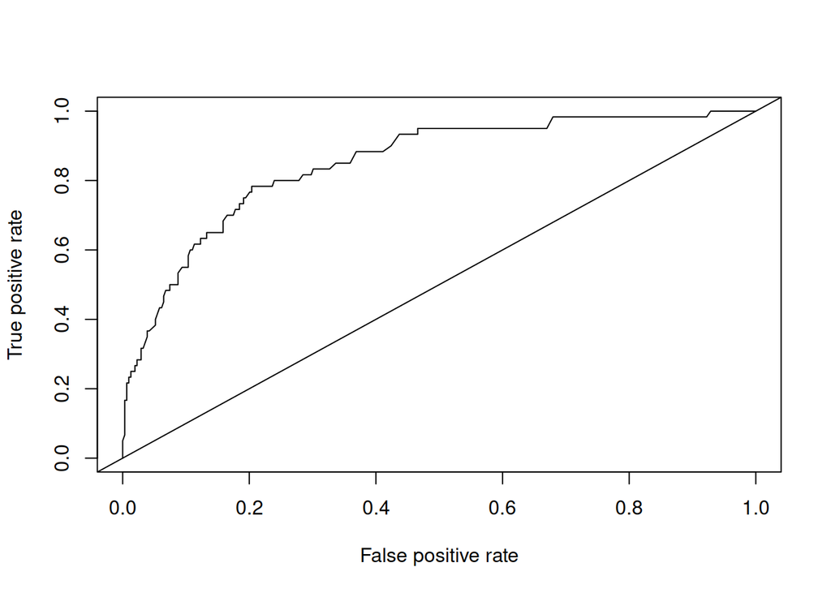

The value of the Area Under the Curve (AUC) is important to be able to compare models, later we will try to optimize this model. This would be the value of the momentum:

```
## [1] 0.8495685
```

At this point, it is up to the company to decide on the target and the level of tolerance for false positives and negatives. As an example, it is assumed that the company wants to focus on true positives, setting a minimum of 70% of cases.

```
##      cut       fpr       tpr
## 68 0.228 0.1650485 0.7000000
## 69 0.224 0.1747573 0.7000000
## 70 0.222 0.1779935 0.7166667
## 71 0.220 0.1812298 0.7166667
## 72 0.218 0.1844660 0.7166667
## 73 0.216 0.1844660 0.7333333
```

As an exercise, it is intended to increase the sensitivity since the cost of losing an employee is high and the increase in false positives does not really represent a major impact.

### Optimizing Parameters

Hyper parameters to optimize:

- ‘mtry’: number of variables that are randomly selected at each decision point.
- ‘min_n’: minimum number of samples needed to split an internal node.

Cross validation with four folds is used. This method divides the data set into a defined amount and performs the training and evaluation process with each one of them and finally performs a summary of the results obtained to determine the best performing one.

```
## #  4-fold cross-validation
## # A tibble: 4 × 2
##   splits            id
##   <list>            <chr>
## 1 <split [825/276]> Fold1
## 2 <split [826/275]> Fold2
## 3 <split [826/275]> Fold3
## 4 <split [826/275]> Fold4
```

Next, the metrics are collected, the best model is chosen and visualized:

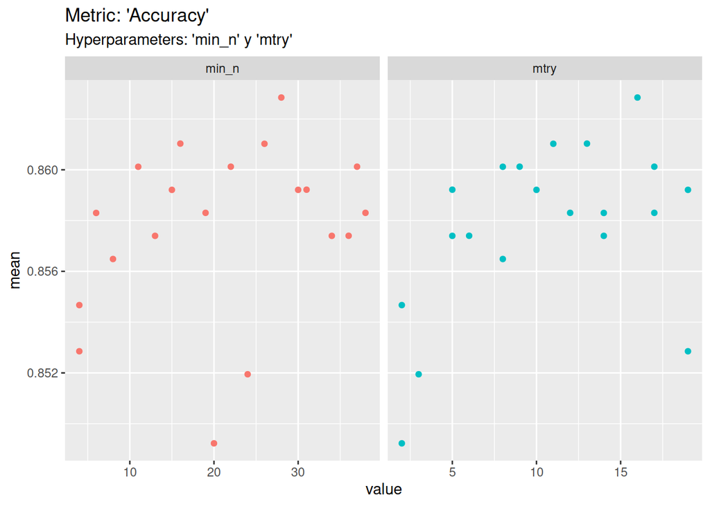

This value should be as high as possible, as this will allow a higher accuracy. In this scenario it is clear, at least for the hyper parameter ‘mtry’, that it is the values around the range between 10 and 15 that provide a high value of accuracy. On the other hand, for the hyper parameter ‘min_n’ the values are more scattered, so a larger range will be used to find the right one.

With this information, the model is refined and visualized in a better way:

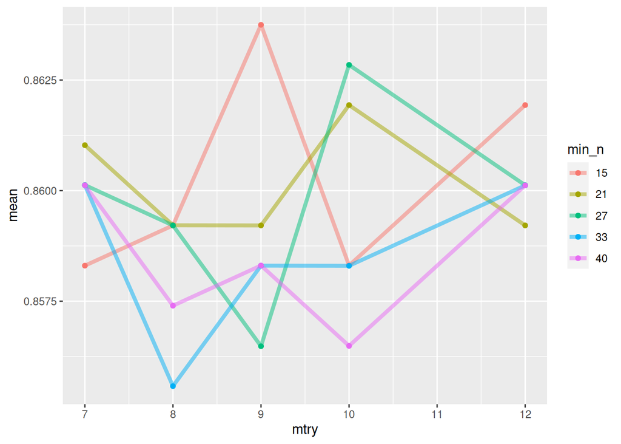

It is observed that the best values for these hyper parameters would be 9 for ‘mtry’ and 15 for ‘min_n’. Therefore, these values are selected and we proceed to run the model again and observe the global importance that the model gives to the variables:

```
## Random Forest Model Specification (classification)
##
## Main Arguments:
##   mtry = 9
##   trees = 501
##   min_n = 15
##
## Computational engine: ranger
```

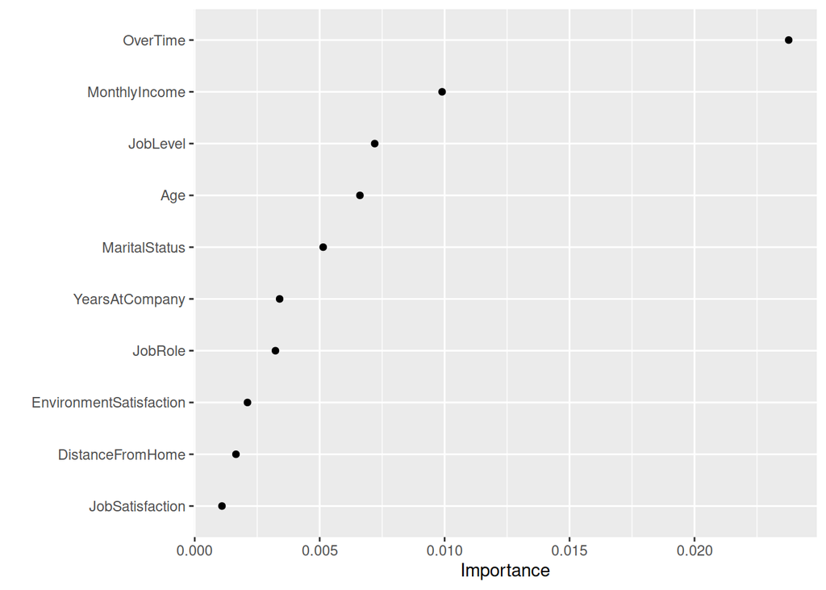

This last graph is important because it indicates that, globally, the variable ‘OverTime’ is the one that has the most weight. After this variable, the next two most important variables are: ‘Monthly Income’ and ‘Job Level’.

Finally, we proceed to see the metrics of the model and then, make the comparison with the first model:

```
## # A tibble: 2 × 4
##   .metric  .estimator .estimate .config
##   <chr>    <chr>          <dbl> <fct>
## 1 accuracy binary         0.859 Preprocessor1_Model1
## 2 roc_auc  binary         0.826 Preprocessor1_Model1
```

```
## [1] "Accuracy: 0.859079"
```

```
## [1] "Precision: 0.681818"
```

```
## [1] "Recall: 0.250000"
```

```
## [1] "Specificity: 0.977346"
```

```
## [1] "F1 score: 0.365854"
```

According to **accuracy**, the model predicts correctly in 85.9% of the cases.

According to **sensitivity**, of all the people who left the company, the model was correct in 25% of the cases.

According to **specificity**, of all the people who did not leave the company, the model correctly predicted 97.7% of the observations.

The **“F1 - Score”** has a value of 36.5%.

## Comparing Both Models

[output not shown]

Although not an excellent performance, the objective was met by having a higher sensitivity ratio than the predecessor model.

The code is in ‘./script.R’ if is any help for anyone.